# Assigment - Naive Bayes DIY

Koko Nguyen - Author

Vy Nguyen - Reviewer

23 March, 2021

```r
library(tidyverse)
library(tm)
library(caret)
library(wordcloud)
library(e1071)
```

## Business Understanding

The chosen dataset for this testing is the Fake News. This dataset indicating sources that are reliable or unreliable.I will use Naive Bayes Classifer to identify which is fake news and which isn’t. I will count the amount of time a word appears in a headline - taking that this headline is from a fake news.Then afterwards find out the probability that the headline is fake, compare to a real one.

## Data Understanding

```r
url <- "https://raw.githubusercontent.com/HAN-M3DM-Data-Mining/assignments/master/datasets/NB-fakenews.csv"
rawDF <- read_csv(url)
head(rawDF)
```

| id | title | author | text | label |
| --- | --- | --- | --- | --- |
| 0 | House Dem Aide: We Didn’t Even See Comey’s Letter Until Jason Chaffetz Tweeted It | Darrell Lucus | House Dem Aide: We Didn’t Even See Comey’s Letter Until Jason Chaffetz Tweeted It By Darrell Lucus on October 30, 2016 Subscribe Jason Chaffetz on the stump in American Fork, Utah ( image courtesy Mic… | 1 |
| 1 | FLYNN: Hillary Clinton, Big Woman on Campus - Breitbart | Daniel J. Flynn | Ever get the feeling your life circles the roundabout rather than heads in a straight line toward the intended destination? [Hillary Clinton remains the big woman on campus in leafy, liberal Wellesley… | 0 |
| 2 | Why the Truth Might Get You Fired | Consortiumnews.com | Why the Truth Might Get You Fired October 29, 2016 \nThe tension between intelligence analysts and political policymakers has always been between honest assessments and desired results, with the latte… | 1 |
| 3 | 15 Civilians Killed In Single US Airstrike Have Been Identified | Jessica Purkiss | Videos 15 Civilians Killed In Single US Airstrike Have Been Identified The rate at which civilians are being killed by American airstrikes in Afghanistan is now higher than it was in 2014 when the US … | 1 |
| 4 | Iranian woman jailed for fictional unpublished story about woman stoned to death for adultery | Howard Portnoy | Print \nAn Iranian woman has been sentenced to six years in prison after Iran’s Revolutionary Guard searched her home and found a notebook that contained a fictional story she’d written about a woman … | 1 |
| 5 | Jackie Mason: Hollywood Would Love Trump if He Bombed North Korea over Lack of Trans Bathrooms (Exclusive Video) - Breitbart | Daniel Nussbaum | In these trying times, Jackie Mason is the Voice of Reason. [In this week’s exclusive clip for Breitbart News, Jackie discusses the looming threat of North Korea, and explains how President Donald Tru… | 0 |

The dataset has 5 variables (columns) and 20800 observations (rows)

After reading the dataset, we find out that variable ID, author and text do not contain any relevant information for our prediction. Hence, we will remove column 1,3 and 4 which represent these data.

```r
cleanDF <- rawDF[c(-1,-3,-4)] %>% na.omit
head(cleanDF)
```

| title | label |
| --- | --- |
| House Dem Aide: We Didn’t Even See Comey’s Letter Until Jason Chaffetz Tweeted It | 1 |
| FLYNN: Hillary Clinton, Big Woman on Campus - Breitbart | 0 |
| Why the Truth Might Get You Fired | 1 |
| 15 Civilians Killed In Single US Airstrike Have Been Identified | 1 |
| Iranian woman jailed for fictional unpublished story about woman stoned to death for adultery | 1 |
| Jackie Mason: Hollywood Would Love Trump if He Bombed North Korea over Lack of Trans Bathrooms (Exclusive Video) - Breitbart | 0 |

The variable label is numeric value with 0: reliable and 1: unreliable. As it indicates whether the tittle belongs to the category “Reliable” or “Unreliable”, we will convert it into a factor variable.

```r
cleanDF$label <- factor(cleanDF$label, levels = c("0", "1"), labels = c("Reliable", "Unreliable")) %>% relevel("Reliable")
class(cleanDF$label)
```

```
[1] "factor"
```

For visually inspect, we create a wordcloud for two variables.

```
transformation drops documentstransformation drops documents
```

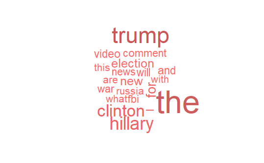

```r
Unreliable <- cleanDF %>% filter(label == "Unreliable")
Reliable <- cleanDF %>% filter(label == "Reliable")

wordcloud(Unreliable$title, max.words = 20, scale = c(4, 0.8), colors= c("indianred1","indianred2","indianred3","indianred"))
```

```
transformation drops documentstransformation drops documents
```

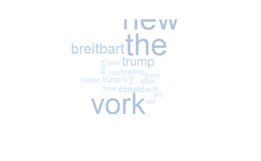

```r
wordcloud(Reliable$title, max.words = 20, scale = c(4, 0.8), colors= c("lightsteelblue1","lightsteelblue2","lightsteelblue3","lightsteelblue"))
```

## Data Preparation

We create a corpus aims to refer to a collection of text document

```r
rawCorpus <- Corpus(VectorSource(cleanDF$title))
inspect(rawCorpus[1:3])
```

```
<<SimpleCorpus>>
Metadata:  corpus specific: 1, document level (indexed): 0
Content:  documents: 3

[1] House Dem Aide: We Didn’t Even See Comey’s Letter Until Jason Chaffetz Tweeted It
[2] FLYNN: Hillary Clinton, Big Woman on Campus - Breitbart
[3] Why the Truth Might Get You Fired
```

The corpus contains 20242 elements which matches with the number of rows in our dataset. We will also change everything to lowercase and remove numbers as these will contain litle information on whether an article is reliable or not

```r
cleanCorpus <- rawCorpus %>% tm_map(tolower) %>% tm_map(removeNumbers)
```

```
transformation drops documentstransformation drops documents
```

```r
inspect(cleanCorpus[1:3])
```

```
<<SimpleCorpus>>
Metadata:  corpus specific: 1, document level (indexed): 0
Content:  documents: 3

[1] house dem aide: we didn’t even see comey’s letter until jason chaffetz tweeted it
[2] flynn: hillary clinton, big woman on campus - breitbart
[3] why the truth might get you fired
```

We also remove stopwords, punctuation and whitespaces

```r
cleanCorpus <- cleanCorpus %>% tm_map(tolower) %>% tm_map(removeWords, stopwords()) %>% tm_map(removePunctuation)
```

```
transformation drops documentstransformation drops documentstransformation drops documents
```

```r
inspect(cleanCorpus[1:3])
```

```
<<SimpleCorpus>>
Metadata:  corpus specific: 1, document level (indexed): 0
Content:  documents: 3

[1] house dem aide  didn’t even see comey’s letter  jason chaffetz tweeted
[2] flynn hillary clinton big woman  campus  breitbart
[3]   truth might get  fired
```

Remove additional whitespace

```r
cleanCorpus <- cleanCorpus %>% tm_map(stripWhitespace)
```

```
transformation drops documents
```

```r
inspect(cleanCorpus[1:3])
```

```
<<SimpleCorpus>>
Metadata:  corpus specific: 1, document level (indexed): 0
Content:  documents: 3

[1] house dem aide didn’t even see comey’s letter jason chaffetz tweeted
[2] flynn hillary clinton big woman campus breitbart
[3]  truth might get fired
```

Compare with the raw version

```r
tibble(Raw = rawCorpus$content[1:3], Clean = cleanCorpus$content[1:3])
```

| Raw | Clean |
| --- | --- |
| House Dem Aide: We Didn’t Even See Comey’s Letter Until Jason Chaffetz Tweeted It | house dem aide didn’t even see comey’s letter jason chaffetz tweeted |
| FLYNN: Hillary Clinton, Big Woman on Campus - Breitbart | flynn hillary clinton big woman campus breitbart |
| Why the Truth Might Get You Fired | truth might get fired |

After cleaning up the text, we transform the messages to a matrix

```r
cleanDTM <- cleanCorpus %>% DocumentTermMatrix
inspect(cleanDTM)
```

```
<<DocumentTermMatrix (documents: 20242, terms: 27804)>>
Non-/sparse entries: 172564/562636004
Sparsity           : 100%
Maximal term length: 62
Weighting          : term frequency (tf)
Sample             :
       Terms
Docs    ’ breitbart clinton donald hillary new times trump will
  1140  0         0       0      0       0   0     0     0    0
  15808 0         0       0      0       0   0     0     0    0
  17565 0         0       0      0       0   0     0     0    0
  18006 0         0       0      0       0   0     0     0    0
  19415 0         0       0      0       0   0     0     0    0
  2042  0         0       0      0       0   1     0     0    1
  311   0         0       0      0       0   0     0     0    0
  3304  0         0       0      0       0   0     0     0    0
  5614  0         0       0      0       0   0     0     0    0
  8750  0         0       0      0       0   0     0     0    0
       Terms
Docs    york
  1140     0
  15808    0
  17565    0
  18006    0
  19415    0
  2042     0
  311      0
  3304     0
  5614     0
  8750     0
```

Dataset will be splitted into train and test sets

```r
# Create split indices
set.seed(1234)
trainIndex <- createDataPartition(cleanDF$label, p = .75,
                                  list = FALSE,
                                  times = 1)
head(trainIndex)
```

```
     Resample1
[1,]         1
[2,]         2
[3,]         3
[4,]         5
[5,]        10
[6,]        11
```

```r
# Apply split indices to DF
trainDF <- cleanDF[trainIndex, ]
testDF <- cleanDF[-trainIndex, ]
```

```r
# Apply split indices to Corpus
trainCorpus <- cleanCorpus[trainIndex]
testCorpus <- cleanCorpus[-trainIndex]
```

```r
# Apply split indices to DTM
trainDTM <- cleanDTM[trainIndex, ]
testDTM <- cleanDTM[-trainIndex, ]
```

Eliminate words with low frequencies

```r
freqWords <- trainDTM %>% findFreqTerms(10)
trainDTM <-  DocumentTermMatrix(trainCorpus, list(dictionary = freqWords))
testDTM <-  DocumentTermMatrix(testCorpus, list(dictionary = freqWords))
```

We will now transform the numerical matrix of words count into a factor that indicates whether the words appear in the document or not

```r
convert_counts <- function(x) {
  x <- ifelse(x > 0, 1, 0) %>% factor(levels = c(0,1), labels = c("No", "Yes"))
}

nColsDTM <- dim(trainDTM)[2]
trainDTM <- apply(trainDTM, MARGIN = 2, convert_counts)
testDTM <- apply(testDTM, MARGIN = 2, convert_counts)

head(trainDTM[,1:10])
```

```
    Terms
Docs aide  comey’s dem   didn’t even  house jason letter see
   1 "Yes" "Yes"   "Yes" "Yes"  "Yes" "Yes" "Yes" "Yes"  "Yes"
   2 "No"  "No"    "No"  "No"   "No"  "No"  "No"  "No"   "No"
   3 "No"  "No"    "No"  "No"   "No"  "No"  "No"  "No"   "No"
   4 "No"  "No"    "No"  "No"   "No"  "No"  "No"  "No"   "No"
   5 "No"  "No"    "No"  "No"   "No"  "No"  "No"  "No"   "No"
   6 "No"  "No"    "No"  "No"   "No"  "No"  "No"  "No"   "No"
    Terms
Docs big
   1 "No"
   2 "Yes"
   3 "No"
   4 "No"
   5 "No"
   6 "No"
```

## Modeling

```r
nbayesModel <-  naiveBayes(trainDTM, trainDF$label, laplace = 1)
```

```r
predVec <- predict(nbayesModel, testDTM)
confusionMatrix(predVec, testDF$label, positive = "Unreliable", dnn = c("Prediction", "True"))
```

```
Confusion Matrix and Statistics

            True
Prediction   Reliable Unreliable
  Reliable       2281         74
  Unreliable      315       2389

               Accuracy : 0.9231
                 95% CI : (0.9154, 0.9303)
    No Information Rate : 0.5131
    P-Value [Acc > NIR] : < 2.2e-16

                  Kappa : 0.8465

 Mcnemar's Test P-Value : < 2.2e-16

            Sensitivity : 0.9700
            Specificity : 0.8787
         Pos Pred Value : 0.8835
         Neg Pred Value : 0.9686
             Prevalence : 0.4869
         Detection Rate : 0.4722
   Detection Prevalence : 0.5345
      Balanced Accuracy : 0.9243

       'Positive' Class : Unreliable
```

## Evaluation and Deployment

The model has an accuracy rate of 92,3% which is quite a good result. Also noticed that in some cases the model still wrongly show a headline is reliable whilst it isnt and vice versa.